# Bayesian GLM Part6

Author

Murray Logan

Published

09/09/2025

# 1 Preparations

Load the necessary libraries

```r
library(tidyverse) # for data wrangling etc
library(rstanarm) # for fitting models in STAN
library(cmdstanr) # for cmdstan
library(brms) # for fitting models in STAN
library(standist) # for exploring distributions
library(HDInterval) # for HPD intervals
library(posterior) # for posterior draws
library(coda) # for diagnostics
library(bayesplot) # for diagnostics
library(ggmcmc) # for MCMC diagnostics
library(DHARMa) # for residual diagnostics
library(rstan) # for interfacing with STAN
library(emmeans) # for marginal means etc
library(broom) # for tidying outputs
library(tidybayes) # for more tidying outputs
library(ggeffects) # for partial plots
library(broom.mixed) # for summarising models
library(ggeffects) # for partial effects plots
library(bayestestR) # for ROPE
library(see) # for some plots
library(easystats) # for the easystats ecosystem
library(ggridges) # for ridge plots
library(patchwork) # for multiple plots
library(modelsummary) # for data and model summaries
theme_set(theme_grey()) # put the default ggplot theme back
source("helperFunctions.R")
```

# 2 Scenario

An ecologist studying a rocky shore at Phillip Island, in southeastern Australia, was interested in how clumps of intertidal mussels are maintained (Quinn 1988). In particular, he wanted to know how densities of adult mussels affected recruitment of young individuals from the plankton. As with most marine invertebrates, recruitment is highly patchy in time, so he expected to find seasonal variation, and the interaction between season and density - whether effects of adult mussel density vary across seasons - was the aspect of most interest.

The data were collected from four seasons, and with two densities of adult mussels. The experiment consisted of clumps of adult mussels attached to the rocks. These clumps were then brought back to the laboratory, and the number of baby mussels recorded. There were 3-6 replicate clumps for each density and season combination.

**Table** 1: Format of the quinn.csv data file

| SEASON | DENSITY | RECRUITS | SQRTRECRUITS | GROUP |
| --- | --- | --- | --- | --- |
| Spring | Low | 15 | 3.87 | SpringLow |
| .. | .. | .. | .. | .. |
| Spring | High | 11 | 3.32 | SpringHigh |
| .. | .. | .. | .. | .. |
| Summer | Low | 21 | 4.58 | SummerLow |
| .. | .. | .. | .. | .. |
| Summer | High | 34 | 5.83 | SummerHigh |
| .. | .. | .. | .. | .. |
| Autumn | Low | 14 | 3.74 | AutumnLow |
| .. | .. | .. | .. | .. |

**Table** 2: Description of the variables in the quinn data file

| **SEASON** | Categorical listing of Season in which mussel clumps were collected  independent variable |
| --- | --- |
| **DENSITY** | Categorical listing of the density of mussels within mussel clump  independent variable |
| **RECRUITS** | The number of mussel recruits  response variable |
| **SQRTRECRUITS** | Square root transformation of RECRUITS - needed to meet the test assumptions |
| **GROUPS** | Categorical listing of Season/Density combinations - used for checking ANOVA assumptions |

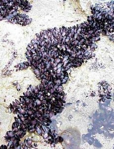

**Figure** 1: Mussel

# 3 Read in the data

```r
quinn <- read_csv("../data/quinn.csv", trim_ws = TRUE)
```

**glimpse**

```r
glimpse(quinn)
```

```
Rows: 42
Columns: 5
$ SEASON       <chr> "Spring", "Spring", "Spring", "Spring", "Spring", "Spring…
$ DENSITY      <chr> "Low", "Low", "Low", "Low", "Low", "High", "High", "High"…
$ RECRUITS     <dbl> 15, 10, 13, 13, 5, 11, 10, 15, 10, 13, 1, 21, 31, 21, 18,…
$ SQRTRECRUITS <dbl> 3.872983, 3.162278, 3.605551, 3.605551, 2.236068, 3.31662…
$ GROUP        <chr> "SpringLow", "SpringLow", "SpringLow", "SpringLow", "Spri…
```

**head**

```r
## Explore the first 6 rows of the data
head(quinn)
```

```
# A tibble: 6 × 5
  SEASON DENSITY RECRUITS SQRTRECRUITS GROUP
  <chr>  <chr>      <dbl>        <dbl> <chr>
1 Spring Low           15         3.87 SpringLow
2 Spring Low           10         3.16 SpringLow
3 Spring Low           13         3.61 SpringLow
4 Spring Low           13         3.61 SpringLow
5 Spring Low            5         2.24 SpringLow
6 Spring High          11         3.32 SpringHigh
```

**str**

```r
str(quinn)
```

```
spc_tbl_ [42 × 5] (S3: spec_tbl_df/tbl_df/tbl/data.frame)
 $ SEASON      : chr [1:42] "Spring" "Spring" "Spring" "Spring" ...
 $ DENSITY     : chr [1:42] "Low" "Low" "Low" "Low" ...
 $ RECRUITS    : num [1:42] 15 10 13 13 5 11 10 15 10 13 ...
 $ SQRTRECRUITS: num [1:42] 3.87 3.16 3.61 3.61 2.24 ...
 $ GROUP       : chr [1:42] "SpringLow" "SpringLow" "SpringLow" "SpringLow" ...
 - attr(*, "spec")=
  .. cols(
  ..   SEASON = col_character(),
  ..   DENSITY = col_character(),
  ..   RECRUITS = col_double(),
  ..   SQRTRECRUITS = col_double(),
  ..   GROUP = col_character()
  .. )
 - attr(*, "problems")=<externalptr>
```

**Easystats (datawizard)**

```r
quinn |> datawizard::data_codebook()
```

```
quinn (42 rows and 5 variables, 5 shown)

ID | Name         | Type      | Missings |     Values |          N
---+--------------+-----------+----------+------------+-----------
1  | SEASON       | character | 0 (0.0%) |     Autumn | 10 (23.8%)
   |              |           |          |     Spring | 11 (26.2%)
   |              |           |          |     Summer | 12 (28.6%)
   |              |           |          |     Winter |  9 (21.4%)
---+--------------+-----------+----------+------------+-----------
2  | DENSITY      | character | 0 (0.0%) |       High | 24 (57.1%)
   |              |           |          |        Low | 18 (42.9%)
---+--------------+-----------+----------+------------+-----------
3  | RECRUITS     | numeric   | 0 (0.0%) |    [0, 69] |         42
---+--------------+-----------+----------+------------+-----------
4  | SQRTRECRUITS | numeric   | 0 (0.0%) |  [0, 8.31] |         42
---+--------------+-----------+----------+------------+-----------
5  | GROUP        | character | 0 (0.0%) | AutumnHigh |  6 (14.3%)
   |              |           |          |  AutumnLow |  4 ( 9.5%)
   |              |           |          | SpringHigh |  6 (14.3%)
   |              |           |          |  SpringLow |  5 (11.9%)
   |              |           |          | SummerHigh |  6 (14.3%)
   |              |           |          |  SummerLow |  6 (14.3%)
   |              |           |          | WinterHigh |  6 (14.3%)
   |              |           |          |  WinterLow |  3 ( 7.1%)
------------------------------------------------------------------
```

**Skim (modelsummary)**

Unique

Missing Pct.

Mean

SD

Min

Median

Max

Histogram

RECRUITS

25

0

18.3

15.7

0.0

13.5

69.0

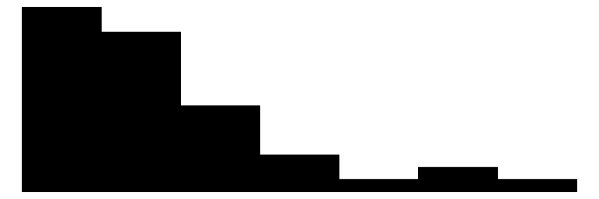

SQRTRECRUITS

25

0

3.9

1.9

0.0

3.7

8.3

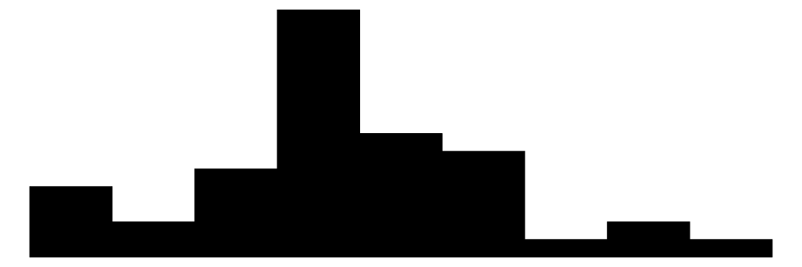

N

%

SEASON

Autumn

10

23.8

Spring

11

26.2

Summer

12

28.6

Winter

9

21.4

DENSITY

High

24

57.1

Low

18

42.9

GROUP

AutumnHigh

6

14.3

AutumnLow

4

9.5

SpringHigh

6

14.3

SpringLow

5

11.9

SummerHigh

6

14.3

SummerLow

6

14.3

WinterHigh

6

14.3

WinterLow

3

7.1

```r
quinn |> modelsummary::datasummary_skim()
```

SEASON

DENSITY

Unique

Missing Pct.

Mean

SD

Min

Median

Max

Histogram

RECRUITS

Spring

Low

4

0

11.2

3.9

5.0

13.0

15.0

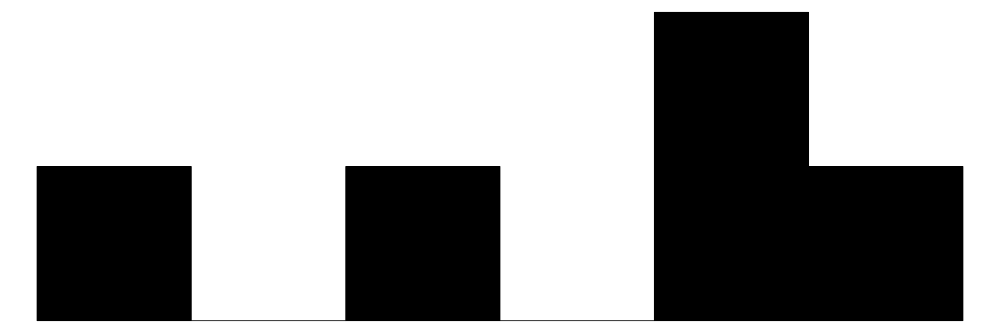

Spring

High

5

0

10.0

4.8

1.0

10.5

15.0

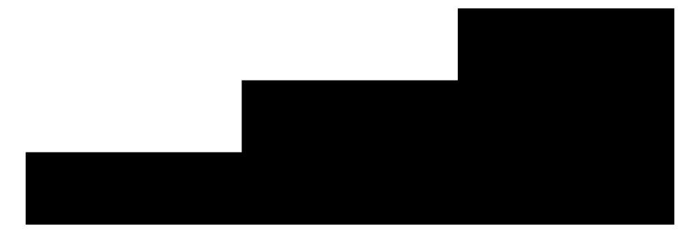

Summer

Low

5

0

22.0

6.1

14.0

21.0

31.0

[figure not shown]

Summer

High

6

0

48.2

15.0

28.0

51.5

69.0

[figure not shown]

Autumn

Low

4

0

18.2

3.1

14.0

19.0

21.0

[figure not shown]

Autumn

High

5

0

19.7

11.9

4.0

17.5

36.0

[figure not shown]

Winter

Low

2

0

2.7

4.6

0.0

0.0

8.0

[figure not shown]

Winter

High

5

0

5.7

3.3

1.0

5.0

10.0

[figure not shown]

```r
quinn |>
  dplyr::select(-SQRTRECRUITS) |>
  modelsummary::datasummary_skim(
    type = "numeric",
    by = c("SEASON", "DENSITY")
  )
```

# 4 Exploratory data analysis

Model formula:
$$\begin{align}
y_i &\sim{} \mathcal{NB}(\lambda_i, \theta)\\
ln(\mu_i) &= \beta_0 + \sum_{j=1}^nT_{[i],j}.\beta_j\\
\beta_0 &\sim{} \mathcal{N}(2.4, 0.2)\\
\beta_{[1,2,3]} &\sim{} \mathcal{N}(0, 2.5)\\
\end{align}$$

where $\beta_{0}$ is the y-intercept (mean of the first group), $\beta_{[1,2,3]}$ are the vector of effects parameters (contrasting each group mean to that of the first group and $T{[i],j}$ represents a $i$ by $j$ model matrix is a model matrix representing the season, density and their interaction on mussel recruitment.

OR alternatively, we could write this as

Model formula:
$$\begin{align}
y_i &\sim{} \mathcal{NB}(\lambda_i, \theta)\\
ln(\mu_i) &= \boldsymbol{\beta} \bf{X_i}\\
\beta_0 &\sim{} \mathcal{N}(2.4, 0.2)\\
\beta_{[1,2,3]} &\sim{} \mathcal{N}(0, 2.5)\\
\end{align}$$

where $\beta_{0}$ is the y-intercept (mean of the first group), $\beta_{[1,2,3]}$ are the vector of effects parameters (contrasting each group mean to that of the first group and $\boldsymbol{\beta}$ is a vector of effects parameters (including the intercept) and $\bf{X_i}$ is a model matrix representing the intercept and treatment contrasts for the effects of density and season on mussel recruitment.

```r
## A recent bug has infiltrated emmeans such that SEASON seems
## to be some sort of keyword.  So in order to prevent downstream issues
## when declaring season as a factor, we will also alter its name...
quinn <- quinn |>
  mutate(
    fSEASON = factor(SEASON,
      levels = c("Spring", "Summer", "Autumn", "Winter")
    ),
    DENSITY = factor(DENSITY)
  )
```

# 5 Exploratory data analysis

```r
quinn |> head()
```

```
# A tibble: 6 × 6
  SEASON DENSITY RECRUITS SQRTRECRUITS GROUP      fSEASON
  <chr>  <fct>      <dbl>        <dbl> <chr>      <fct>
1 Spring Low           15         3.87 SpringLow  Spring
2 Spring Low           10         3.16 SpringLow  Spring
3 Spring Low           13         3.61 SpringLow  Spring
4 Spring Low           13         3.61 SpringLow  Spring
5 Spring Low            5         2.24 SpringLow  Spring
6 Spring High          11         3.32 SpringHigh Spring
```

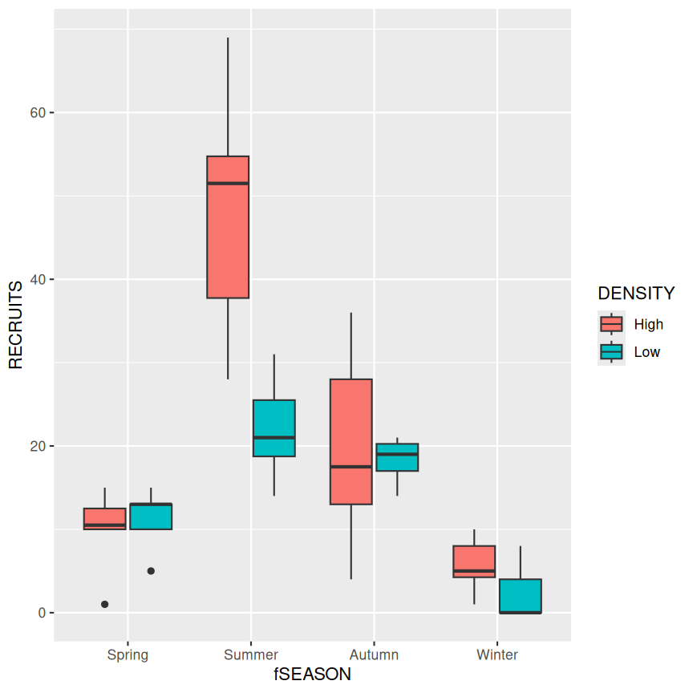

```r
quinn |> ggplot(aes(y = RECRUITS, x = fSEASON, fill = DENSITY)) +
  geom_boxplot()
```

**Conclusions:**

**rstanarm**

**Using default priors**

In `rstanarm`, the default priors are designed to be weakly informative. They are chosen to provide moderate regularisation (to help prevent over-fitting) and help stabilise the computations.

```r
quinn_rstanarmP <- stan_glm(RECRUITS ~ fSEASON * DENSITY,
  data = quinn,
  family = poisson(link = "log"),
  refresh = 0,
  chains = 3, iter = 5000, thin = 5, warmup = 2000
)
```

```r
quinn_rstanarmP |> prior_summary()
```

```
Priors for model 'quinn_rstanarmP'
------
Intercept (after predictors centered)
 ~ normal(location = 0, scale = 2.5)

Coefficients
  Specified prior:
    ~ normal(location = [0,0,0,...], scale = [2.5,2.5,2.5,...])
  Adjusted prior:
    ~ normal(location = [0,0,0,...], scale = [5.47,5.80,6.02,...])
------
See help('prior_summary.stanreg') for more details
```

This tells us:

- for the intercept, when the family is Poisson, it is using a normal prior with a mean of 0 and a standard deviation of 2.5. The 2.5 is used for all intercepts. It is often scaled, but only if it is larger than 2.5 is the scaled version kept.
- for the coefficients (in this case, the individual effects), the default prior is a normal prior centred around 0 with a standard deviations of 5.47, 5/8, 6.02 etc. This is then adjusted for the scale of the data by dividing the 2.5 by the standard deviation of the numerical dummy variables for the predictor (then rounded).

```r
2.5 / apply(model.matrix(~ fSEASON * DENSITY, quinn)[, -1], 2, sd)
```

```
           fSEASONSummer            fSEASONAutumn            fSEASONWinter
                5.467708                 5.799380                 6.019749
              DENSITYLow fSEASONSummer:DENSITYLow fSEASONAutumn:DENSITYLow
                4.991312                 7.058781                 8.414625
fSEASONWinter:DENSITYLow
                9.590995
```

- there is no auxiliary prior as we are employing a Poisson distribution.

**Assessing priors**

```r
quinn_rstanarm1 <- stan_glm(RECRUITS ~ fSEASON * DENSITY,
  data = quinn,
  family = poisson(link = "log"),
  prior_PD = TRUE,
  refresh = 0,
  chains = 3, iter = 5000, thin = 5, warmup = 2000
)
```

**ggpredict**

```
Data points may overlap. Use the `jitter` argument to add some amount of
  random variation to the location of data points and avoid overplotting.
```

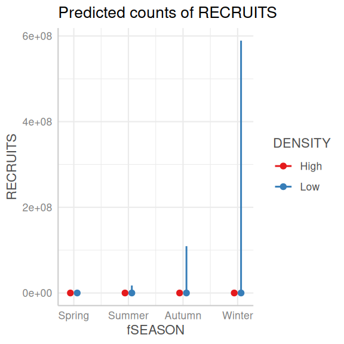

```r
quinn_rstanarm1 |>
  ggpredict(~ fSEASON + DENSITY) |>
  plot(show_data = TRUE)
```

```
Data points may overlap. Use the `jitter` argument to add some amount of
  random variation to the location of data points and avoid overplotting.
```

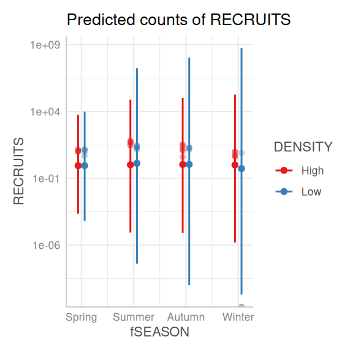

```r
quinn_rstanarm1 |>
  ggpredict(~ fSEASON + DENSITY) |>
  plot(show_data = TRUE) |>
  wrap_plots() &
  scale_y_log10()
```

```
Data points may overlap. Use the `jitter` argument to add some amount of
  random variation to the location of data points and avoid overplotting.
```

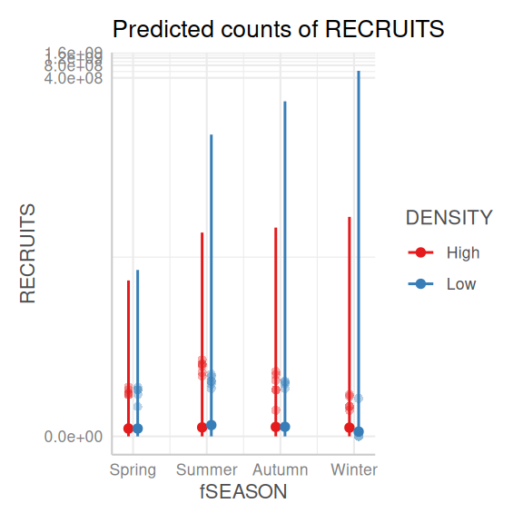

```r
## although, since there are zeros...
quinn_rstanarm1 |>
  ggpredict(~ fSEASON + DENSITY) |>
  plot(show_data = TRUE, jitter = FALSE) |>
  wrap_plots() &
  scale_y_continuous(trans = scales::pseudo_log_trans())
```

**ggemmeans**

```
Data points may overlap. Use the `jitter` argument to add some amount of
  random variation to the location of data points and avoid overplotting.
```

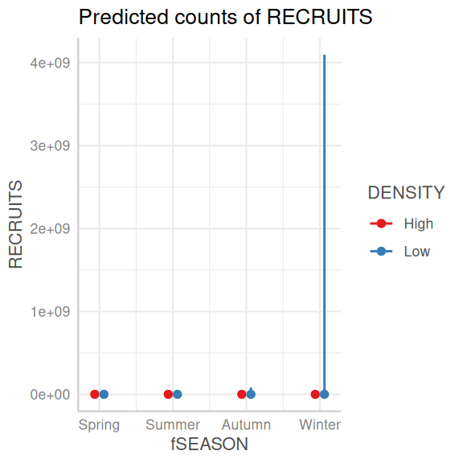

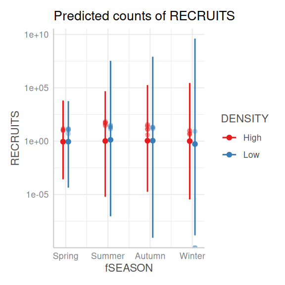

```r
quinn_rstanarm1 |>
  ggemmeans(~ fSEASON + DENSITY) |>
  plot(show_data = TRUE) |>
  plot(show_data = TRUE) |>
  wrap_plots() &
  scale_y_log10()
```

```
Data points may overlap. Use the `jitter` argument to add some amount of
  random variation to the location of data points and avoid overplotting.
```

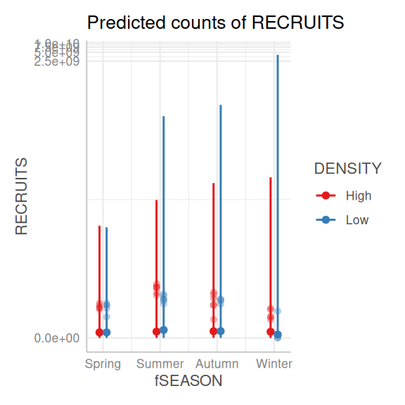

```r
## although, since there are zeros...
quinn_rstanarm1 |>
  ggemmeans(~ fSEASON + DENSITY) |>
  plot(show_data = TRUE, jitter = FALSE) |>
  wrap_plots() &
  scale_y_continuous(trans = scales::pseudo_log_trans())
```

**Conclusions:**

- we see that the range of predictions is fairly wide and the predicted means could range from 0 to very large (perhaps too large).

**Defining priors**

The following link provides some guidance about defining priors. [https://github.com/stan-dev/stan/wiki/Prior-Choice-Recommendations]

When defining our own priors, we typically do not want them to be scaled.

Remember the above are applied on the link scale.

I will also overlay the raw data for comparison.

```r
quinn |>
  group_by(fSEASON, DENSITY) |>
  summarise(
    Mean = log(mean(RECRUITS)),
    SD = log(sd(RECRUITS))
  )
```

```
# A tibble: 8 × 4
# Groups:   fSEASON [4]
  fSEASON DENSITY  Mean    SD
  <fct>   <fct>   <dbl> <dbl>
1 Spring  High    2.30   1.57
2 Spring  Low     2.42   1.36
3 Summer  High    3.87   2.71
4 Summer  Low     3.09   1.81
5 Autumn  High    2.98   2.48
6 Autumn  Low     2.90   1.13
7 Winter  High    1.73   1.20
8 Winter  Low     0.981  1.53
```

```r
log(sd(quinn$RECRUITS)) /
  apply(model.matrix(~ fSEASON * DENSITY, data = quinn), 2, sd)
```

```
             (Intercept)            fSEASONSummer            fSEASONAutumn
                     Inf                 6.024998                 6.390475
           fSEASONWinter               DENSITYLow fSEASONSummer:DENSITYLow
                6.633304                 5.500045                 7.778238
fSEASONAutumn:DENSITYLow fSEASONWinter:DENSITYLow
                9.272276                10.568545
```

```r
quinn_rstanarm2 <- stan_glm(RECRUITS ~ fSEASON * DENSITY,
  data = quinn,
  family = poisson(link = "log"),
  prior_intercept = normal(2.3, 2, autoscale = FALSE),
  prior = normal(0, 10, autoscale = FALSE),
  prior_PD = TRUE,
  refresh = 0,
  chains = 3, iter = 5000, thin = 5, warmup = 2000
)
```

**ggpredict**

```
Data points may overlap. Use the `jitter` argument to add some amount of
  random variation to the location of data points and avoid overplotting.
```

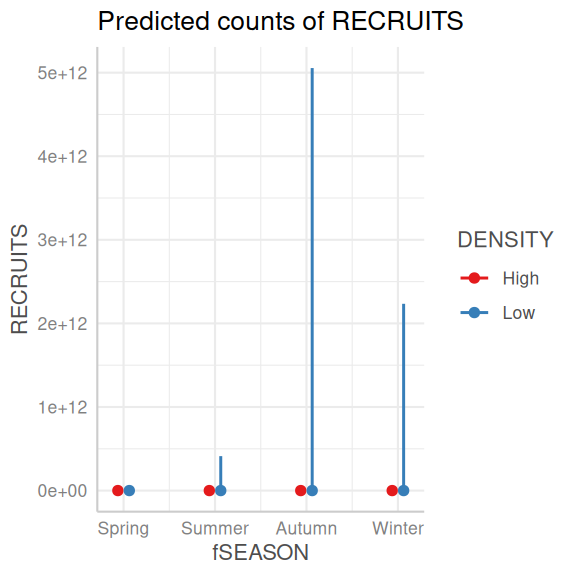

```r
quinn_rstanarm2 |>
  ggpredict(~ fSEASON + DENSITY) |>
  plot(show_data = TRUE)
```

```
Data points may overlap. Use the `jitter` argument to add some amount of
  random variation to the location of data points and avoid overplotting.
```

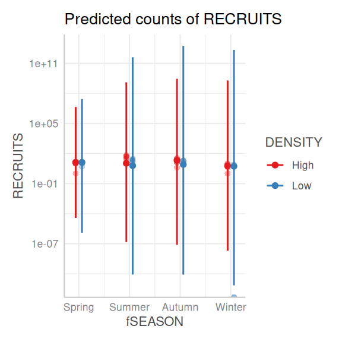

```r
quinn_rstanarm2 |>
  ggpredict(~ fSEASON + DENSITY) |>
  plot(show_data = TRUE) |>
  wrap_plots() &
  scale_y_log10()
```

```
Data points may overlap. Use the `jitter` argument to add some amount of
  random variation to the location of data points and avoid overplotting.
```

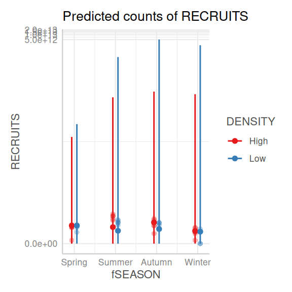

```r
## although, since there are zeros...
quinn_rstanarm2 |>
  ggpredict(~ fSEASON + DENSITY) |>
  plot(show_data = TRUE, jitter = FALSE) |>
  wrap_plots() &
  scale_y_continuous(trans = scales::pseudo_log_trans())
```

**ggemmeans**

```
Data points may overlap. Use the `jitter` argument to add some amount of
  random variation to the location of data points and avoid overplotting.
```

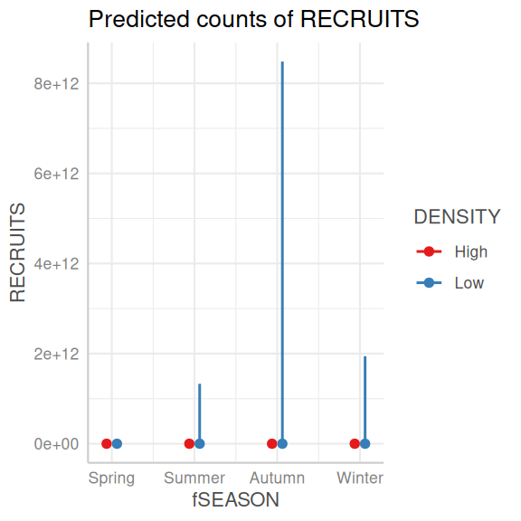

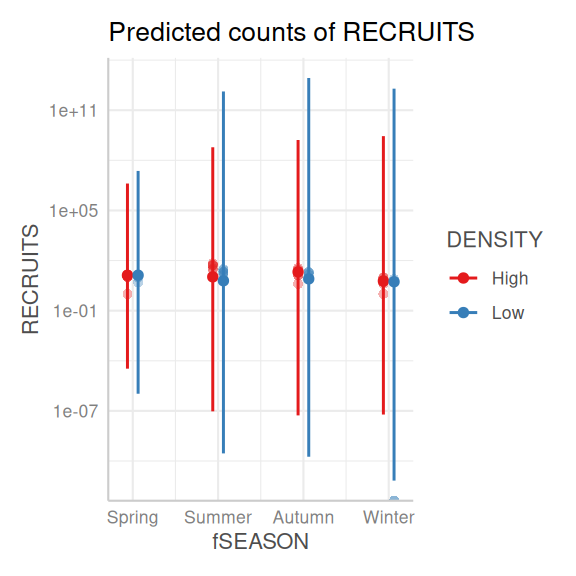

```r
quinn_rstanarm2 |>
  ggemmeans(~ fSEASON + DENSITY) |>
  plot(show_data = TRUE) |>
  plot(show_data = TRUE) |>
  wrap_plots() &
  scale_y_log10()
```

```
Data points may overlap. Use the `jitter` argument to add some amount of
  random variation to the location of data points and avoid overplotting.
```

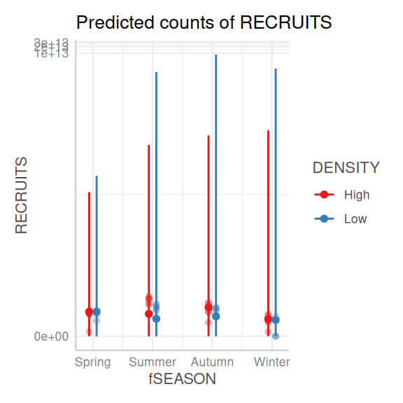

```r
## although, since there are zeros...
quinn_rstanarm2 |>
  ggemmeans(~ fSEASON + DENSITY) |>
  plot(show_data = TRUE, jitter = FALSE) |>
  wrap_plots() &
  scale_y_continuous(trans = scales::pseudo_log_trans())
```

Now lets refit, conditioning on the data.

```r
quinn_rstanarm3 <- quinn_rstanarm2 |> update(prior_PD = FALSE)
```

**Plotting prior and posterior**

```
Drawing from prior...
```

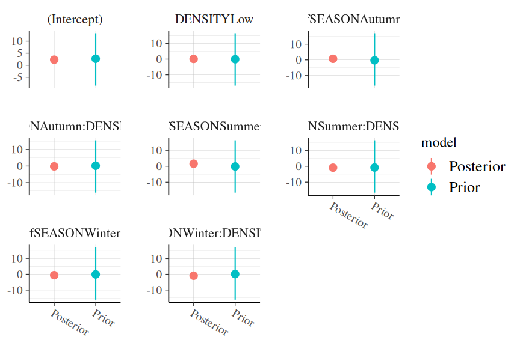

```r
quinn_rstanarm3 |> posterior_vs_prior(
  color_by = "vs", group_by = TRUE,
  facet_args = list(scales = "free_y")
)
```

**Conclusions:**

- in each case, the prior is substantially wider than the posterior, suggesting that the posterior is not biased towards the prior.

**ggpredict**

```
Data points may overlap. Use the `jitter` argument to add some amount of
  random variation to the location of data points and avoid overplotting.
```

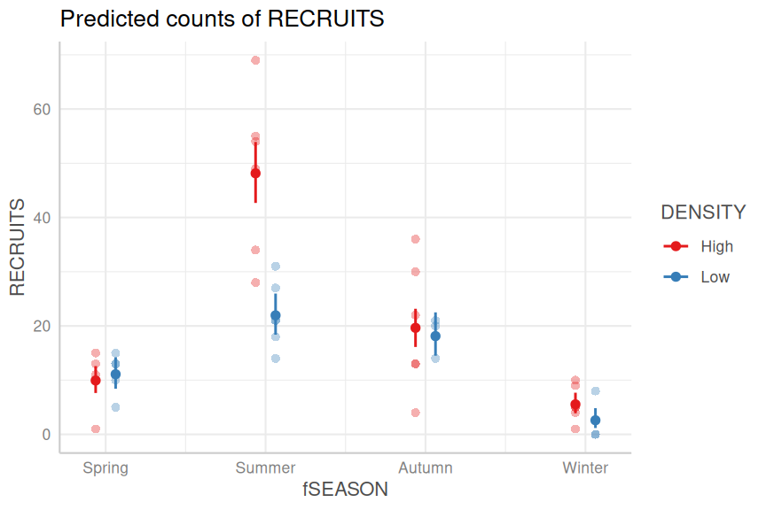

```r
quinn_rstanarm3 |>
  ggpredict(~ fSEASON + DENSITY) |>
  plot(show_data = TRUE)
```

**ggemmeans**

```
Data points may overlap. Use the `jitter` argument to add some amount of
  random variation to the location of data points and avoid overplotting.
```

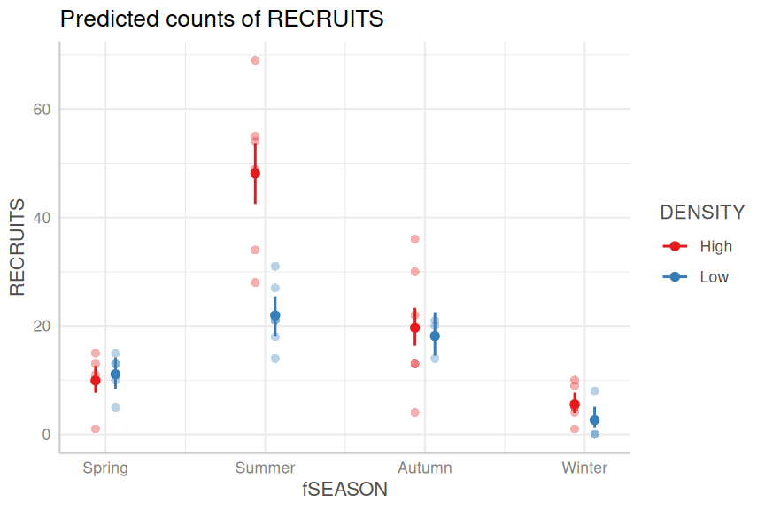

```r
quinn_rstanarm3 |>
  ggemmeans(~ fSEASON + DENSITY) |>
  plot(show_data = TRUE)
```

**brms**

**Using default priors**

In `brms`, the default priors are designed to be weakly informative. They are chosen to provide moderate regularisation (to help prevent over-fitting) and help stabilise the computations.

Unlike `rstanarm`, `brms` models must be compiled before they start sampling. For most models, the compilation of the stan code takes around 45 seconds.

```r
quinn_form <- bf(RECRUITS ~ fSEASON * DENSITY, family = poisson(link = "log"))
```

```r
get_prior(quinn_form, data = quinn)
```

```
                  prior     class                     coef group resp dpar nlpar lb ub       source
                 (flat)         b                                                           default
                 (flat)         b               DENSITYLow                             (vectorized)
                 (flat)         b            fSEASONAutumn                             (vectorized)
                 (flat)         b fSEASONAutumn:DENSITYLow                             (vectorized)
                 (flat)         b            fSEASONSummer                             (vectorized)
                 (flat)         b fSEASONSummer:DENSITYLow                             (vectorized)
                 (flat)         b            fSEASONWinter                             (vectorized)
                 (flat)         b fSEASONWinter:DENSITYLow                             (vectorized)
 student_t(3, 2.6, 2.5) Intercept                                                           default
```

**Defining priors**

Remember that the priors are applied on the link (in this case, log) scale. Given that there are some zero’s, we need to add a small constant before logarithmic transform. It might also necessary to use means/sd rather than median/mad

```r
quinn |>
  group_by(fSEASON, DENSITY) |>
  summarise(
    Mean = mean(log(RECRUITS + 1)),
    Median = median(log(RECRUITS + 1)),
    SD = sd(log(RECRUITS + 1)),
    MAD = mad(log(RECRUITS + 1))
  )
```

```
# A tibble: 8 × 6
# Groups:   fSEASON [4]
  fSEASON DENSITY  Mean Median    SD   MAD
  <fct>   <fct>   <dbl>  <dbl> <dbl> <dbl>
1 Spring  High    2.23    2.44 0.767 0.179
2 Spring  Low     2.45    2.64 0.391 0.198
3 Summer  High    3.85    3.96 0.328 0.263
4 Summer  Low     3.11    3.09 0.270 0.287
5 Autumn  High    2.84    2.89 0.725 0.589
6 Autumn  Low     2.95    2.99 0.171 0.109
7 Winter  High    1.76    1.79 0.611 0.514
8 Winter  Low     0.732   0    1.27  0
```

- $\beta_0$: normal centred at 2.5 with a standard deviation of 0.2
- $\beta_1$: normal centred at 0 with a standard deviation of 2.5

```r
quinn_form <- bf(RECRUITS ~ fSEASON * DENSITY, family = poisson(link = "log"))
priors <- prior(normal(2.5, 0.2), class = "Intercept") +
  prior(normal(0, 2.5), class = "b")
quinn_brm2 <- brm(quinn_form,
  data = quinn,
  prior = priors,
  sample_prior = "only",
  refresh = 0,
  chains = 3,
  iter = 5000,
  thin = 5,
  warmup = 2500,
  backend = "rstan"
)
```

**ggpredict**

```
Data points may overlap. Use the `jitter` argument to add some amount of
  random variation to the location of data points and avoid overplotting.
```

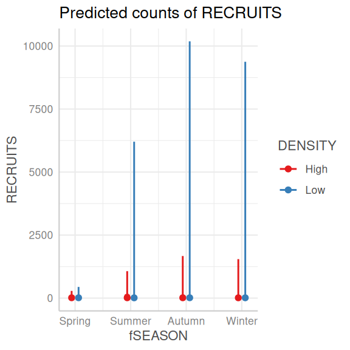

```r
quinn_brm2 |>
  ggpredict(~ fSEASON + DENSITY) |>
  plot(show_data = TRUE)
```

```
Data points may overlap. Use the `jitter` argument to add some amount of
  random variation to the location of data points and avoid overplotting.
```

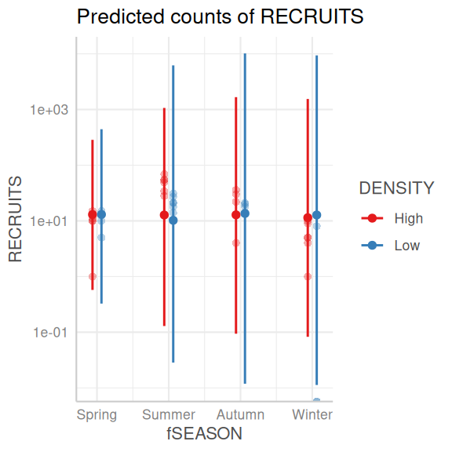

```r
quinn_brm2 |>
  ggpredict(~ fSEASON + DENSITY) |>
  plot(show_data = TRUE) +
  scale_y_log10()
```

```
Data points may overlap. Use the `jitter` argument to add some amount of
  random variation to the location of data points and avoid overplotting.
```

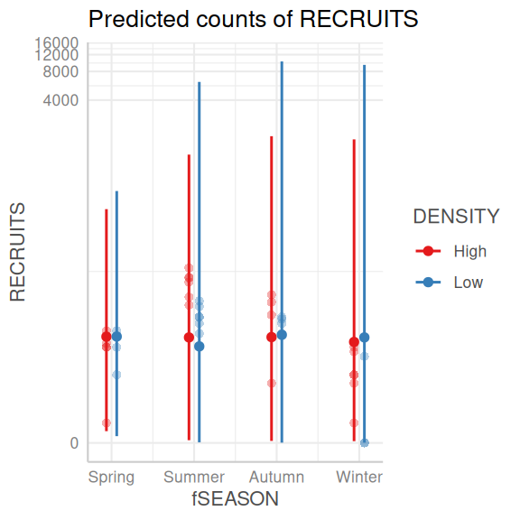

```r
## Or since there are zeros
quinn_brm2 |>
  ggpredict(~ fSEASON + DENSITY) |>
  plot(show_data = TRUE) +
  scale_y_continuous(trans = scales::pseudo_log_trans())
```

**ggemmeans**

```
Data points may overlap. Use the `jitter` argument to add some amount of
  random variation to the location of data points and avoid overplotting.
```

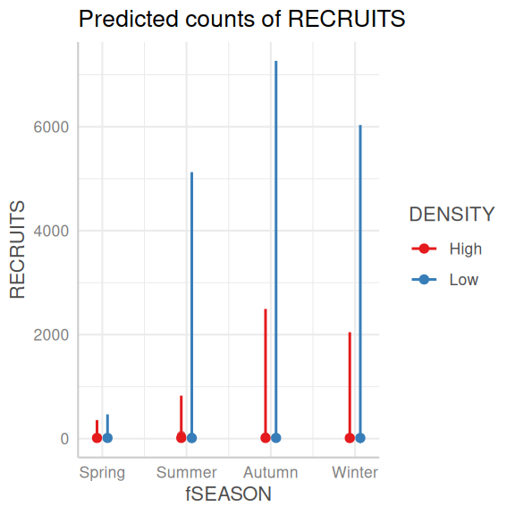

```r
quinn_brm2 |>
  ggemmeans(~ fSEASON + DENSITY) |>
  plot(show_data = TRUE)
```